# Risk Factor Analysis

## Outcome Variable

**Outcome Variable:** stunted

## Predictor Variables

**Intervention Variable:** tr

**Adjustment Set:**

unadjusted

## Stratifying Variables

The analysis was stratified on these variable(s):

- gagebrth
- agecat
- studyid
- country

## Data Summary

| gagebrth | agecat | studyid | country | tr | stunted | n_cell | n |
| --- | --- | --- | --- | --- | --- | --- | --- |
| <259 | 6 months | ki1000304b-SAS-CompFeed | INDIA | Control | 0 | 158 | 478 |
| <259 | 6 months | ki1000304b-SAS-CompFeed | INDIA | Control | 1 | 65 | 478 |
| <259 | 6 months | ki1000304b-SAS-CompFeed | INDIA | Other | 0 | 177 | 478 |
| <259 | 6 months | ki1000304b-SAS-CompFeed | INDIA | Other | 1 | 78 | 478 |
| [259-273) | 6 months | ki1000304b-SAS-CompFeed | INDIA | Control | 0 | 42 | 117 |
| [259-273) | 6 months | ki1000304b-SAS-CompFeed | INDIA | Control | 1 | 16 | 117 |
| [259-273) | 6 months | ki1000304b-SAS-CompFeed | INDIA | Other | 0 | 48 | 117 |
| [259-273) | 6 months | ki1000304b-SAS-CompFeed | INDIA | Other | 1 | 11 | 117 |
| <259 | Birth | ki1000304b-SAS-CompFeed | INDIA | Control | 0 | 41 | 117 |
| <259 | Birth | ki1000304b-SAS-CompFeed | INDIA | Control | 1 | 14 | 117 |
| <259 | Birth | ki1000304b-SAS-CompFeed | INDIA | Other | 0 | 44 | 117 |
| <259 | Birth | ki1000304b-SAS-CompFeed | INDIA | Other | 1 | 18 | 117 |
| [259-273) | Birth | ki1000304b-SAS-CompFeed | INDIA | Control | 0 | 12 | 27 |
| [259-273) | Birth | ki1000304b-SAS-CompFeed | INDIA | Control | 1 | 3 | 27 |
| [259-273) | Birth | ki1000304b-SAS-CompFeed | INDIA | Other | 0 | 9 | 27 |
| [259-273) | Birth | ki1000304b-SAS-CompFeed | INDIA | Other | 1 | 3 | 27 |
| [273-287) | 6 months | ki1000304b-SAS-CompFeed | INDIA | Control | 0 | 11 | 19 |
| [273-287) | 6 months | ki1000304b-SAS-CompFeed | INDIA | Control | 1 | 1 | 19 |
| [273-287) | 6 months | ki1000304b-SAS-CompFeed | INDIA | Other | 0 | 6 | 19 |
| [273-287) | 6 months | ki1000304b-SAS-CompFeed | INDIA | Other | 1 | 1 | 19 |
| >=287 | 6 months | ki1000304b-SAS-CompFeed | INDIA | Control | 0 | 1 | 1 |
| >=287 | 6 months | ki1066203-TanzaniaChild2 | TANZANIA, UNITED REPUBLIC OF | Control | 0 | 88 | 407 |
| >=287 | 6 months | ki1066203-TanzaniaChild2 | TANZANIA, UNITED REPUBLIC OF | Control | 1 | 5 | 407 |
| >=287 | 6 months | ki1066203-TanzaniaChild2 | TANZANIA, UNITED REPUBLIC OF | Other | 0 | 100 | 407 |
| >=287 | 6 months | ki1066203-TanzaniaChild2 | TANZANIA, UNITED REPUBLIC OF | Other | 1 | 11 | 407 |
| >=287 | 6 months | ki1066203-TanzaniaChild2 | TANZANIA, UNITED REPUBLIC OF | Zinc | 0 | 187 | 407 |
| >=287 | 6 months | ki1066203-TanzaniaChild2 | TANZANIA, UNITED REPUBLIC OF | Zinc | 1 | 16 | 407 |
| [273-287) | 6 months | ki1066203-TanzaniaChild2 | TANZANIA, UNITED REPUBLIC OF | Control | 0 | 136 | 625 |
| [273-287) | 6 months | ki1066203-TanzaniaChild2 | TANZANIA, UNITED REPUBLIC OF | Control | 1 | 19 | 625 |
| [273-287) | 6 months | ki1066203-TanzaniaChild2 | TANZANIA, UNITED REPUBLIC OF | Other | 0 | 136 | 625 |

[output cut: 207 more lines]

The following strata were considered:

- gagebrth: [259-273), agecat: 24 months, studyid: iLiNS_DYADM_LNS, country: MALAWI
- gagebrth: [259-273), agecat: 24 months, studyid: ki1066203-TanzaniaChild2, country: TANZANIA, UNITED REPUBLIC OF
- gagebrth: [259-273), agecat: 24 months, studyid: ki1119695-PROBIT, country: BELARUS
- gagebrth: [259-273), agecat: 24 months, studyid: ki1135781-COHORTS, country: GUATEMALA
- gagebrth: [259-273), agecat: 24 months, studyid: ki1148112-iLiNS-DYAD-M, country: MALAWI
- gagebrth: [259-273), agecat: 24 months, studyid: kiGH5241-JiVitA-3, country: BANGLADESH
- gagebrth: [259-273), agecat: 6 months, studyid: iLiNS_DYADM_LNS, country: MALAWI
- gagebrth: [259-273), agecat: 6 months, studyid: ki1000304b-SAS-CompFeed, country: INDIA
- gagebrth: [259-273), agecat: 6 months, studyid: ki1066203-TanzaniaChild2, country: TANZANIA, UNITED REPUBLIC OF
- gagebrth: [259-273), agecat: 6 months, studyid: ki1119695-PROBIT, country: BELARUS
- gagebrth: [259-273), agecat: 6 months, studyid: ki1135781-COHORTS, country: GUATEMALA
- gagebrth: [259-273), agecat: 6 months, studyid: ki1148112-iLiNS-DYAD-M, country: MALAWI
- gagebrth: [259-273), agecat: 6 months, studyid: kiGH5241-JiVitA-3, country: BANGLADESH
- gagebrth: [259-273), agecat: Birth, studyid: ki1000304b-SAS-CompFeed, country: INDIA
- gagebrth: [259-273), agecat: Birth, studyid: ki1119695-PROBIT, country: BELARUS
- gagebrth: [259-273), agecat: Birth, studyid: ki1135781-COHORTS, country: GUATEMALA
- gagebrth: [259-273), agecat: Birth, studyid: kiGH5241-JiVitA-3, country: BANGLADESH
- gagebrth: [273-287), agecat: 24 months, studyid: iLiNS_DYADM_LNS, country: MALAWI
- gagebrth: [273-287), agecat: 24 months, studyid: ki1066203-TanzaniaChild2, country: TANZANIA, UNITED REPUBLIC OF
- gagebrth: [273-287), agecat: 24 months, studyid: ki1119695-PROBIT, country: BELARUS
- gagebrth: [273-287), agecat: 24 months, studyid: ki1135781-COHORTS, country: GUATEMALA
- gagebrth: [273-287), agecat: 24 months, studyid: ki1148112-iLiNS-DYAD-M, country: MALAWI
- gagebrth: [273-287), agecat: 24 months, studyid: kiGH5241-JiVitA-3, country: BANGLADESH
- gagebrth: [273-287), agecat: 6 months, studyid: iLiNS_DYADM_LNS, country: MALAWI
- gagebrth: [273-287), agecat: 6 months, studyid: ki1000304b-SAS-CompFeed, country: INDIA
- gagebrth: [273-287), agecat: 6 months, studyid: ki1066203-TanzaniaChild2, country: TANZANIA, UNITED REPUBLIC OF
- gagebrth: [273-287), agecat: 6 months, studyid: ki1119695-PROBIT, country: BELARUS
- gagebrth: [273-287), agecat: 6 months, studyid: ki1135781-COHORTS, country: GUATEMALA
- gagebrth: [273-287), agecat: 6 months, studyid: ki1148112-iLiNS-DYAD-M, country: MALAWI
- gagebrth: [273-287), agecat: 6 months, studyid: kiGH5241-JiVitA-3, country: BANGLADESH
- gagebrth: [273-287), agecat: Birth, studyid: iLiNS_DYADM_LNS, country: MALAWI
- gagebrth: [273-287), agecat: Birth, studyid: ki1119695-PROBIT, country: BELARUS
- gagebrth: [273-287), agecat: Birth, studyid: ki1135781-COHORTS, country: GUATEMALA
- gagebrth: [273-287), agecat: Birth, studyid: ki1148112-iLiNS-DYAD-M, country: MALAWI
- gagebrth: [273-287), agecat: Birth, studyid: kiGH5241-JiVitA-3, country: BANGLADESH
- gagebrth: <259, agecat: 24 months, studyid: iLiNS_DYADM_LNS, country: MALAWI
- gagebrth: <259, agecat: 24 months, studyid: ki1135781-COHORTS, country: GUATEMALA
- gagebrth: <259, agecat: 24 months, studyid: ki1148112-iLiNS-DYAD-M, country: MALAWI
- gagebrth: <259, agecat: 24 months, studyid: kiGH5241-JiVitA-3, country: BANGLADESH
- gagebrth: <259, agecat: 6 months, studyid: iLiNS_DYADM_LNS, country: MALAWI
- gagebrth: <259, agecat: 6 months, studyid: ki1000304b-SAS-CompFeed, country: INDIA
- gagebrth: <259, agecat: 6 months, studyid: ki1066203-TanzaniaChild2, country: TANZANIA, UNITED REPUBLIC OF
- gagebrth: <259, agecat: 6 months, studyid: ki1135781-COHORTS, country: GUATEMALA
- gagebrth: <259, agecat: 6 months, studyid: ki1148112-iLiNS-DYAD-M, country: MALAWI
- gagebrth: <259, agecat: 6 months, studyid: kiGH5241-JiVitA-3, country: BANGLADESH
- gagebrth: <259, agecat: Birth, studyid: ki1000304b-SAS-CompFeed, country: INDIA
- gagebrth: <259, agecat: Birth, studyid: ki1135781-COHORTS, country: GUATEMALA
- gagebrth: <259, agecat: Birth, studyid: kiGH5241-JiVitA-3, country: BANGLADESH
- gagebrth: >=287, agecat: 24 months, studyid: iLiNS_DYADM_LNS, country: MALAWI
- gagebrth: >=287, agecat: 24 months, studyid: ki1119695-PROBIT, country: BELARUS
- gagebrth: >=287, agecat: 24 months, studyid: ki1135781-COHORTS, country: GUATEMALA
- gagebrth: >=287, agecat: 24 months, studyid: ki1148112-iLiNS-DYAD-M, country: MALAWI
- gagebrth: >=287, agecat: 24 months, studyid: kiGH5241-JiVitA-3, country: BANGLADESH
- gagebrth: >=287, agecat: 6 months, studyid: iLiNS_DYADM_LNS, country: MALAWI
- gagebrth: >=287, agecat: 6 months, studyid: ki1000304b-SAS-CompFeed, country: INDIA
- gagebrth: >=287, agecat: 6 months, studyid: ki1066203-TanzaniaChild2, country: TANZANIA, UNITED REPUBLIC OF
- gagebrth: >=287, agecat: 6 months, studyid: ki1119695-PROBIT, country: BELARUS
- gagebrth: >=287, agecat: 6 months, studyid: ki1135781-COHORTS, country: GUATEMALA
- gagebrth: >=287, agecat: 6 months, studyid: ki1148112-iLiNS-DYAD-M, country: MALAWI
- gagebrth: >=287, agecat: 6 months, studyid: kiGH5241-JiVitA-3, country: BANGLADESH
- gagebrth: >=287, agecat: Birth, studyid: ki1119695-PROBIT, country: BELARUS
- gagebrth: >=287, agecat: Birth, studyid: ki1135781-COHORTS, country: GUATEMALA
- gagebrth: >=287, agecat: Birth, studyid: kiGH5241-JiVitA-3, country: BANGLADESH

### Dropped Strata

Some strata were dropped due to rare outcomes:

- gagebrth: [259-273), agecat: Birth, studyid: ki1000304b-SAS-CompFeed, country: INDIA
- gagebrth: [273-287), agecat: 6 months, studyid: ki1000304b-SAS-CompFeed, country: INDIA
- gagebrth: >=287, agecat: 6 months, studyid: ki1000304b-SAS-CompFeed, country: INDIA
- gagebrth: [273-287), agecat: 24 months, studyid: ki1066203-TanzaniaChild2, country: TANZANIA, UNITED REPUBLIC OF
- gagebrth: [259-273), agecat: 24 months, studyid: ki1066203-TanzaniaChild2, country: TANZANIA, UNITED REPUBLIC OF
- gagebrth: [273-287), agecat: Birth, studyid: ki1119695-PROBIT, country: BELARUS
- gagebrth: >=287, agecat: 24 months, studyid: ki1119695-PROBIT, country: BELARUS
- gagebrth: [259-273), agecat: Birth, studyid: ki1135781-COHORTS, country: GUATEMALA
- gagebrth: [273-287), agecat: Birth, studyid: ki1135781-COHORTS, country: GUATEMALA
- gagebrth: >=287, agecat: Birth, studyid: ki1135781-COHORTS, country: GUATEMALA
- gagebrth: >=287, agecat: 24 months, studyid: ki1135781-COHORTS, country: GUATEMALA
- gagebrth: [273-287), agecat: 24 months, studyid: ki1135781-COHORTS, country: GUATEMALA
- gagebrth: [259-273), agecat: 24 months, studyid: ki1135781-COHORTS, country: GUATEMALA
- gagebrth: <259, agecat: 24 months, studyid: ki1135781-COHORTS, country: GUATEMALA
- gagebrth: [273-287), agecat: Birth, studyid: ki1148112-iLiNS-DYAD-M, country: MALAWI
- gagebrth: >=287, agecat: 24 months, studyid: ki1148112-iLiNS-DYAD-M, country: MALAWI
- gagebrth: [259-273), agecat: 24 months, studyid: ki1148112-iLiNS-DYAD-M, country: MALAWI
- gagebrth: [273-287), agecat: 24 months, studyid: ki1148112-iLiNS-DYAD-M, country: MALAWI
- gagebrth: <259, agecat: 24 months, studyid: ki1148112-iLiNS-DYAD-M, country: MALAWI
- gagebrth: >=287, agecat: 24 months, studyid: kiGH5241-JiVitA-3, country: BANGLADESH
- gagebrth: <259, agecat: 24 months, studyid: kiGH5241-JiVitA-3, country: BANGLADESH
- gagebrth: [259-273), agecat: 24 months, studyid: kiGH5241-JiVitA-3, country: BANGLADESH
- gagebrth: [273-287), agecat: 24 months, studyid: kiGH5241-JiVitA-3, country: BANGLADESH
- gagebrth: [273-287), agecat: Birth, studyid: iLiNS_DYADM_LNS, country: MALAWI
- gagebrth: >=287, agecat: 24 months, studyid: iLiNS_DYADM_LNS, country: MALAWI
- gagebrth: [259-273), agecat: 24 months, studyid: iLiNS_DYADM_LNS, country: MALAWI
- gagebrth: [273-287), agecat: 24 months, studyid: iLiNS_DYADM_LNS, country: MALAWI
- gagebrth: <259, agecat: 24 months, studyid: iLiNS_DYADM_LNS, country: MALAWI

## Methods Detail

We’re interested in the causal parameters $E[Y_a]$ for all values of $a \in \mathcal{A}$. These parameters represent the mean outcome if, possibly contrary to fact, we intervened to set all units to have $A=a$. Under the randomization and positivity assumptions, these are identified by the statistical parameters $\psi_a=E_W[E_{Y|A,W}(Y|A=a,W)]$. In addition, we’re interested in the mean of $Y$, $E[Y]$ under no intervention (the observed mean). We will estimate these parameters by using SuperLearner to fit the relevant likelihood factors – $E_{Y|A,W}(Y|A=a,W)$ and $p(A=a|W)$, and then updating our likelihood fit using a joint TMLE.

For unadjusted analyses ($W=\{\}$), initial likelihoods were estimated using Lrnr_glm to estimate the simple $E(Y|A)$ and Lrnr_mean to estimate $p(A)$. For adjusted analyses, a small library containing Lrnr_glmnet, Lrnr_xgboost, and Lrnr_mean was used.

Having estimated these parameters, we will then use the delta method to estimate relative risks and attributable risks relative to a prespecified baseline level of $A$.

```
##           stunted
## tr           0
##   Control  518
##   LNS        0
##   Maternal 592
##   Other      0
##   Zinc       0
```

# Results Detail

## Results Plots

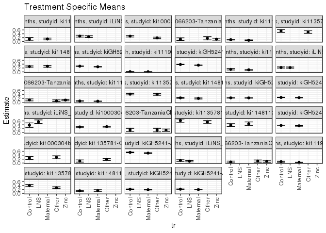

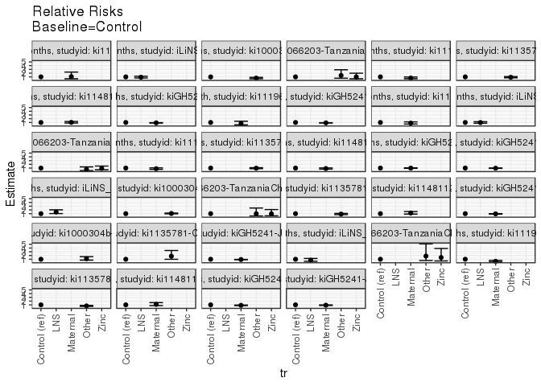

[figure not shown]

[figure not shown]

## Results Table

### Parameter: TSM

| gagebrth | agecat | studyid | country | intervention_level | baseline_level | estimate | ci_lower | ci_upper |
| --- | --- | --- | --- | --- | --- | --- | --- | --- |
| [273-287) | Birth | kiGH5241-JiVitA-3 | BANGLADESH | Control | NA | 0.2447044 | 0.2358722 | 0.2535366 |
| [273-287) | Birth | kiGH5241-JiVitA-3 | BANGLADESH | Maternal | NA | 0.2357972 | 0.2269345 | 0.2446599 |
| [273-287) | 6 months | iLiNS_DYADM_LNS | MALAWI | Control | NA | 0.2267442 | 0.1939794 | 0.2595090 |
| [273-287) | 6 months | iLiNS_DYADM_LNS | MALAWI | LNS | NA | 0.2229299 | 0.1918144 | 0.2540455 |
| [273-287) | 6 months | ki1066203-TanzaniaChild2 | TANZANIA, UNITED REPUBLIC OF | Control | NA | 0.1225806 | 0.0709099 | 0.1742514 |
| [273-287) | 6 months | ki1066203-TanzaniaChild2 | TANZANIA, UNITED REPUBLIC OF | Other | NA | 0.0810811 | 0.0370699 | 0.1250923 |
| [273-287) | 6 months | ki1066203-TanzaniaChild2 | TANZANIA, UNITED REPUBLIC OF | Zinc | NA | 0.1118012 | 0.0773546 | 0.1462478 |
| [273-287) | 6 months | ki1119695-PROBIT | BELARUS | Control | NA | 0.0661417 | 0.0542522 | 0.0780313 |
| [273-287) | 6 months | ki1119695-PROBIT | BELARUS | Maternal | NA | 0.0551712 | 0.0468208 | 0.0635215 |
| [273-287) | 6 months | ki1135781-COHORTS | GUATEMALA | Control | NA | 0.4198473 | 0.3805174 | 0.4591772 |
| [273-287) | 6 months | ki1135781-COHORTS | GUATEMALA | Other | NA | 0.4039735 | 0.3619910 | 0.4459560 |
| [273-287) | 6 months | ki1148112-iLiNS-DYAD-M | MALAWI | Control | NA | 0.2267442 | 0.2054098 | 0.2480786 |
| [273-287) | 6 months | ki1148112-iLiNS-DYAD-M | MALAWI | Maternal | NA | 0.1981982 | 0.1699369 | 0.2264595 |
| [273-287) | 6 months | kiGH5241-JiVitA-3 | BANGLADESH | Control | NA | 0.2274201 | 0.2171742 | 0.2376660 |
| [273-287) | 6 months | kiGH5241-JiVitA-3 | BANGLADESH | Maternal | NA | 0.2250559 | 0.2143219 | 0.2357900 |
| [273-287) | 24 months | ki1119695-PROBIT | BELARUS | Control | NA | 0.1311475 | 0.0953966 | 0.1668984 |
| [273-287) | 24 months | ki1119695-PROBIT | BELARUS | Maternal | NA | 0.1079545 | 0.0851874 | 0.1307217 |
| <259 | Birth | ki1000304b-SAS-CompFeed | INDIA | Control | NA | 0.2545455 | 0.1787065 | 0.3303844 |
| <259 | Birth | ki1000304b-SAS-CompFeed | INDIA | Other | NA | 0.2903226 | 0.2160103 | 0.3646348 |
| <259 | Birth | ki1135781-COHORTS | GUATEMALA | Control | NA | 0.1020408 | 0.0470331 | 0.1570486 |
| <259 | Birth | ki1135781-COHORTS | GUATEMALA | Other | NA | 0.1851852 | 0.1327859 | 0.2375844 |
| <259 | Birth | kiGH5241-JiVitA-3 | BANGLADESH | Control | NA | 0.5450311 | 0.5310471 | 0.5590150 |
| <259 | Birth | kiGH5241-JiVitA-3 | BANGLADESH | Maternal | NA | 0.5058104 | 0.4907681 | 0.5208527 |
| <259 | 6 months | iLiNS_DYADM_LNS | MALAWI | Control | NA | 0.3846154 | 0.2728362 | 0.4963945 |
| <259 | 6 months | iLiNS_DYADM_LNS | MALAWI | LNS | NA | 0.5555556 | 0.4605615 | 0.6505496 |
| <259 | 6 months | ki1000304b-SAS-CompFeed | INDIA | Control | NA | 0.2914798 | 0.2740875 | 0.3088722 |
| <259 | 6 months | ki1000304b-SAS-CompFeed | INDIA | Other | NA | 0.3058824 | 0.2837852 | 0.3279795 |
| <259 | 6 months | ki1066203-TanzaniaChild2 | TANZANIA, UNITED REPUBLIC OF | Control | NA | 0.1355932 | 0.0480444 | 0.2231421 |
| <259 | 6 months | ki1066203-TanzaniaChild2 | TANZANIA, UNITED REPUBLIC OF | Other | NA | 0.1320755 | 0.0407246 | 0.2234263 |
| <259 | 6 months | ki1066203-TanzaniaChild2 | TANZANIA, UNITED REPUBLIC OF | Zinc | NA | 0.1282051 | 0.0674944 | 0.1889158 |
| <259 | 6 months | ki1135781-COHORTS | GUATEMALA | Control | NA | 0.6153846 | 0.5340103 | 0.6967589 |
| <259 | 6 months | ki1135781-COHORTS | GUATEMALA | Other | NA | 0.5454545 | 0.4791071 | 0.6118019 |
| <259 | 6 months | ki1148112-iLiNS-DYAD-M | MALAWI | Control | NA | 0.3846154 | 0.3125827 | 0.4566481 |
| <259 | 6 months | ki1148112-iLiNS-DYAD-M | MALAWI | Maternal | NA | 0.4523810 | 0.3587170 | 0.5460449 |
| <259 | 6 months | kiGH5241-JiVitA-3 | BANGLADESH | Control | NA | 0.3704319 | 0.3536682 | 0.3871956 |
| <259 | 6 months | kiGH5241-JiVitA-3 | BANGLADESH | Maternal | NA | 0.3493282 | 0.3307055 | 0.3679509 |
| [259-273) | Birth | ki1119695-PROBIT | BELARUS | Control | NA | 0.0106914 | 0.0051603 | 0.0162225 |
| [259-273) | Birth | ki1119695-PROBIT | BELARUS | Maternal | NA | 0.0076336 | 0.0048550 | 0.0104121 |
| [259-273) | Birth | kiGH5241-JiVitA-3 | BANGLADESH | Control | NA | 0.3824979 | 0.3707757 | 0.3942202 |
| [259-273) | Birth | kiGH5241-JiVitA-3 | BANGLADESH | Maternal | NA | 0.3449288 | 0.3340311 | 0.3558264 |
| [259-273) | 6 months | iLiNS_DYADM_LNS | MALAWI | Control | NA | 0.2777778 | 0.2294979 | 0.3260577 |
| [259-273) | 6 months | iLiNS_DYADM_LNS | MALAWI | LNS | NA | 0.2530120 | 0.2080105 | 0.2980136 |
| [259-273) | 6 months | ki1000304b-SAS-CompFeed | INDIA | Control | NA | 0.2758621 | 0.2325222 | 0.3192019 |
| [259-273) | 6 months | ki1000304b-SAS-CompFeed | INDIA | Other | NA | 0.1864407 | 0.1456052 | 0.2272761 |
| [259-273) | 6 months | ki1066203-TanzaniaChild2 | TANZANIA, UNITED REPUBLIC OF | Control | NA | 0.1222222 | 0.0544525 | 0.1899919 |
| [259-273) | 6 months | ki1066203-TanzaniaChild2 | TANZANIA, UNITED REPUBLIC OF | Other | NA | 0.1688312 | 0.0850367 | 0.2526256 |
| [259-273) | 6 months | ki1066203-TanzaniaChild2 | TANZANIA, UNITED REPUBLIC OF | Zinc | NA | 0.1220930 | 0.0730931 | 0.1710929 |
| [259-273) | 6 months | ki1119695-PROBIT | BELARUS | Control | NA | 0.0965330 | 0.0796087 | 0.1134572 |
| [259-273) | 6 months | ki1119695-PROBIT | BELARUS | Maternal | NA | 0.0680000 | 0.0509715 | 0.0850285 |
| [259-273) | 6 months | ki1135781-COHORTS | GUATEMALA | Control | NA | 0.5438596 | 0.4739993 | 0.6137200 |
| [259-273) | 6 months | ki1135781-COHORTS | GUATEMALA | Other | NA | 0.4897959 | 0.4247862 | 0.5548056 |
| [259-273) | 6 months | ki1148112-iLiNS-DYAD-M | MALAWI | Control | NA | 0.2777778 | 0.2439917 | 0.3115638 |
| [259-273) | 6 months | ki1148112-iLiNS-DYAD-M | MALAWI | Maternal | NA | 0.2866242 | 0.2415739 | 0.3316745 |
| [259-273) | 6 months | kiGH5241-JiVitA-3 | BANGLADESH | Control | NA | 0.2951623 | 0.2815834 | 0.3087412 |
| [259-273) | 6 months | kiGH5241-JiVitA-3 | BANGLADESH | Maternal | NA | 0.2655194 | 0.2525761 | 0.2784627 |
| [259-273) | 24 months | ki1119695-PROBIT | BELARUS | Control | NA | 0.1228070 | 0.0393850 | 0.2062290 |
| [259-273) | 24 months | ki1119695-PROBIT | BELARUS | Maternal | NA | 0.1315789 | 0.0857620 | 0.1773958 |
| >=287 | Birth | kiGH5241-JiVitA-3 | BANGLADESH | Control | NA | 0.2128954 | 0.2019771 | 0.2238136 |
| >=287 | Birth | kiGH5241-JiVitA-3 | BANGLADESH | Maternal | NA | 0.1927772 | 0.1810676 | 0.2044869 |
| >=287 | 6 months | iLiNS_DYADM_LNS | MALAWI | Control | NA | 0.1269841 | 0.0890374 | 0.1649309 |
| >=287 | 6 months | iLiNS_DYADM_LNS | MALAWI | LNS | NA | 0.0945946 | 0.0584462 | 0.1307430 |
| >=287 | 6 months | ki1066203-TanzaniaChild2 | TANZANIA, UNITED REPUBLIC OF | Control | NA | 0.0537634 | 0.0078665 | 0.0996604 |
| >=287 | 6 months | ki1066203-TanzaniaChild2 | TANZANIA, UNITED REPUBLIC OF | Other | NA | 0.0990991 | 0.0434454 | 0.1547528 |
| >=287 | 6 months | ki1066203-TanzaniaChild2 | TANZANIA, UNITED REPUBLIC OF | Zinc | NA | 0.0788177 | 0.0417053 | 0.1159301 |
| >=287 | 6 months | ki1119695-PROBIT | BELARUS | Control | NA | 0.0677362 | 0.0424019 | 0.0930705 |
| >=287 | 6 months | ki1119695-PROBIT | BELARUS | Maternal | NA | 0.0309598 | 0.0245464 | 0.0373731 |
| >=287 | 6 months | ki1135781-COHORTS | GUATEMALA | Control | NA | 0.4040404 | 0.3606415 | 0.4474393 |
| >=287 | 6 months | ki1135781-COHORTS | GUATEMALA | Other | NA | 0.2868852 | 0.2424779 | 0.3312925 |
| >=287 | 6 months | ki1148112-iLiNS-DYAD-M | MALAWI | Control | NA | 0.1269841 | 0.1021414 | 0.1518269 |
| >=287 | 6 months | ki1148112-iLiNS-DYAD-M | MALAWI | Maternal | NA | 0.1438356 | 0.1039761 | 0.1836951 |
| >=287 | 6 months | kiGH5241-JiVitA-3 | BANGLADESH | Control | NA | 0.2107884 | 0.1990940 | 0.2224828 |
| >=287 | 6 months | kiGH5241-JiVitA-3 | BANGLADESH | Maternal | NA | 0.1835677 | 0.1710235 | 0.1961119 |

### Parameter: E(Y)

| gagebrth | agecat | studyid | country | intervention_level | baseline_level | estimate | ci_lower | ci_upper |
| --- | --- | --- | --- | --- | --- | --- | --- | --- |
| [273-287) | Birth | kiGH5241-JiVitA-3 | BANGLADESH | NA | NA | 0.2401740 | 0.2276602 | 0.2526878 |
| [273-287) | 6 months | iLiNS_DYADM_LNS | MALAWI | NA | NA | 0.2249240 | 0.1797383 | 0.2701097 |
| [273-287) | 6 months | ki1066203-TanzaniaChild2 | TANZANIA, UNITED REPUBLIC OF | NA | NA | 0.1072000 | 0.0829266 | 0.1314734 |
| [273-287) | 6 months | ki1119695-PROBIT | BELARUS | NA | NA | 0.0604427 | 0.0454707 | 0.0754146 |
| [273-287) | 6 months | ki1135781-COHORTS | GUATEMALA | NA | NA | 0.4113475 | 0.3538129 | 0.4688821 |
| [273-287) | 6 months | ki1148112-iLiNS-DYAD-M | MALAWI | NA | NA | 0.2079208 | 0.1724912 | 0.2433504 |
| [273-287) | 6 months | kiGH5241-JiVitA-3 | BANGLADESH | NA | NA | 0.2262176 | 0.2113794 | 0.2410557 |
| [273-287) | 24 months | ki1119695-PROBIT | BELARUS | NA | NA | 0.1174497 | 0.0745712 | 0.1603281 |
| <259 | Birth | ki1000304b-SAS-CompFeed | INDIA | NA | NA | 0.2735043 | 0.1667295 | 0.3802791 |
| <259 | Birth | ki1135781-COHORTS | GUATEMALA | NA | NA | 0.1315789 | 0.0550764 | 0.2080815 |
| <259 | Birth | kiGH5241-JiVitA-3 | BANGLADESH | NA | NA | 0.5270535 | 0.5064399 | 0.5476672 |
| <259 | 6 months | iLiNS_DYADM_LNS | MALAWI | NA | NA | 0.4545455 | 0.3057184 | 0.6033725 |
| <259 | 6 months | ki1000304b-SAS-CompFeed | INDIA | NA | NA | 0.2991632 | 0.2703526 | 0.3279738 |
| <259 | 6 months | ki1066203-TanzaniaChild2 | TANZANIA, UNITED REPUBLIC OF | NA | NA | 0.1310044 | 0.0872086 | 0.1748002 |
| <259 | 6 months | ki1135781-COHORTS | GUATEMALA | NA | NA | 0.5882353 | 0.4829886 | 0.6934820 |
| <259 | 6 months | ki1148112-iLiNS-DYAD-M | MALAWI | NA | NA | 0.4264706 | 0.3080484 | 0.5448928 |
| <259 | 6 months | kiGH5241-JiVitA-3 | BANGLADESH | NA | NA | 0.3606411 | 0.3355826 | 0.3856997 |
| [259-273) | Birth | ki1119695-PROBIT | BELARUS | NA | NA | 0.0092951 | 0.0029423 | 0.0156479 |
| [259-273) | Birth | kiGH5241-JiVitA-3 | BANGLADESH | NA | NA | 0.3639004 | 0.3477885 | 0.3800123 |
| [259-273) | 6 months | iLiNS_DYADM_LNS | MALAWI | NA | NA | 0.2658960 | 0.1998694 | 0.3319225 |
| [259-273) | 6 months | ki1000304b-SAS-CompFeed | INDIA | NA | NA | 0.2307692 | 0.1658851 | 0.2956534 |
| [259-273) | 6 months | ki1066203-TanzaniaChild2 | TANZANIA, UNITED REPUBLIC OF | NA | NA | 0.1327434 | 0.0965716 | 0.1689151 |
| [259-273) | 6 months | ki1119695-PROBIT | BELARUS | NA | NA | 0.0834252 | 0.0587202 | 0.1081302 |
| [259-273) | 6 months | ki1135781-COHORTS | GUATEMALA | NA | NA | 0.5188679 | 0.4232996 | 0.6144363 |
| [259-273) | 6 months | ki1148112-iLiNS-DYAD-M | MALAWI | NA | NA | 0.2834008 | 0.2270864 | 0.3397152 |
| [259-273) | 6 months | kiGH5241-JiVitA-3 | BANGLADESH | NA | NA | 0.2803681 | 0.2615720 | 0.2991642 |
| [259-273) | 24 months | ki1119695-PROBIT | BELARUS | NA | NA | 0.1263158 | 0.0306200 | 0.2220116 |
| >=287 | Birth | kiGH5241-JiVitA-3 | BANGLADESH | NA | NA | 0.2019391 | 0.1859323 | 0.2179458 |
| >=287 | 6 months | iLiNS_DYADM_LNS | MALAWI | NA | NA | 0.1094891 | 0.0570103 | 0.1619678 |
| >=287 | 6 months | ki1066203-TanzaniaChild2 | TANZANIA, UNITED REPUBLIC OF | NA | NA | 0.0786241 | 0.0524434 | 0.1048048 |
| >=287 | 6 months | ki1119695-PROBIT | BELARUS | NA | NA | 0.0480530 | 0.0200823 | 0.0760237 |
| >=287 | 6 months | ki1135781-COHORTS | GUATEMALA | NA | NA | 0.3393665 | 0.2767986 | 0.4019344 |
| >=287 | 6 months | ki1148112-iLiNS-DYAD-M | MALAWI | NA | NA | 0.1387560 | 0.0917768 | 0.1857352 |
| >=287 | 6 months | kiGH5241-JiVitA-3 | BANGLADESH | NA | NA | 0.1964006 | 0.1792850 | 0.2135163 |

### Parameter: RR

| gagebrth | agecat | studyid | country | intervention_level | baseline_level | estimate | ci_lower | ci_upper |
| --- | --- | --- | --- | --- | --- | --- | --- | --- |
| [273-287) | Birth | kiGH5241-JiVitA-3 | BANGLADESH | Control | Control | 1.0000000 | 1.0000000 | 1.0000000 |
| [273-287) | Birth | kiGH5241-JiVitA-3 | BANGLADESH | Maternal | Control | 0.9636001 | 0.9146727 | 1.0151448 |
| [273-287) | 6 months | iLiNS_DYADM_LNS | MALAWI | Control | Control | 1.0000000 | 1.0000000 | 1.0000000 |
| [273-287) | 6 months | iLiNS_DYADM_LNS | MALAWI | LNS | Control | 0.9831782 | 0.8042320 | 1.2019409 |
| [273-287) | 6 months | ki1066203-TanzaniaChild2 | TANZANIA, UNITED REPUBLIC OF | Control | Control | 1.0000000 | 1.0000000 | 1.0000000 |
| [273-287) | 6 months | ki1066203-TanzaniaChild2 | TANZANIA, UNITED REPUBLIC OF | Other | Control | 0.6614509 | 0.3326798 | 1.3151305 |
| [273-287) | 6 months | ki1066203-TanzaniaChild2 | TANZANIA, UNITED REPUBLIC OF | Zinc | Control | 0.9120628 | 0.5410904 | 1.5373743 |
| [273-287) | 6 months | ki1119695-PROBIT | BELARUS | Control | Control | 1.0000000 | 1.0000000 | 1.0000000 |
| [273-287) | 6 months | ki1119695-PROBIT | BELARUS | Maternal | Control | 0.8341354 | 0.6601322 | 1.0540038 |
| [273-287) | 6 months | ki1135781-COHORTS | GUATEMALA | Control | Control | 1.0000000 | 1.0000000 | 1.0000000 |
| [273-287) | 6 months | ki1135781-COHORTS | GUATEMALA | Other | Control | 0.9621915 | 0.8365623 | 1.1066867 |
| [273-287) | 6 months | ki1148112-iLiNS-DYAD-M | MALAWI | Control | Control | 1.0000000 | 1.0000000 | 1.0000000 |
| [273-287) | 6 months | ki1148112-iLiNS-DYAD-M | MALAWI | Maternal | Control | 0.8741049 | 0.7368346 | 1.0369482 |
| [273-287) | 6 months | kiGH5241-JiVitA-3 | BANGLADESH | Control | Control | 1.0000000 | 1.0000000 | 1.0000000 |
| [273-287) | 6 months | kiGH5241-JiVitA-3 | BANGLADESH | Maternal | Control | 0.9896044 | 0.9267552 | 1.0567157 |
| [273-287) | 24 months | ki1119695-PROBIT | BELARUS | Control | Control | 1.0000000 | 1.0000000 | 1.0000000 |
| [273-287) | 24 months | ki1119695-PROBIT | BELARUS | Maternal | Control | 0.8231534 | 0.5831639 | 1.1619058 |
| <259 | Birth | ki1000304b-SAS-CompFeed | INDIA | Control | Control | 1.0000000 | 1.0000000 | 1.0000000 |
| <259 | Birth | ki1000304b-SAS-CompFeed | INDIA | Other | Control | 1.1405530 | 0.7694920 | 1.6905454 |
| <259 | Birth | ki1135781-COHORTS | GUATEMALA | Control | Control | 1.0000000 | 1.0000000 | 1.0000000 |
| <259 | Birth | ki1135781-COHORTS | GUATEMALA | Other | Control | 1.8148148 | 0.9872412 | 3.3361177 |
| <259 | Birth | kiGH5241-JiVitA-3 | BANGLADESH | Control | Control | 1.0000000 | 1.0000000 | 1.0000000 |
| <259 | Birth | kiGH5241-JiVitA-3 | BANGLADESH | Maternal | Control | 0.9280396 | 0.8922915 | 0.9652198 |
| <259 | 6 months | iLiNS_DYADM_LNS | MALAWI | Control | Control | 1.0000000 | 1.0000000 | 1.0000000 |
| <259 | 6 months | iLiNS_DYADM_LNS | MALAWI | LNS | Control | 1.4444444 | 1.0310003 | 2.0236850 |
| <259 | 6 months | ki1000304b-SAS-CompFeed | INDIA | Control | Control | 1.0000000 | 1.0000000 | 1.0000000 |
| <259 | 6 months | ki1000304b-SAS-CompFeed | INDIA | Other | Control | 1.0494118 | 0.9555727 | 1.1524660 |
| <259 | 6 months | ki1066203-TanzaniaChild2 | TANZANIA, UNITED REPUBLIC OF | Control | Control | 1.0000000 | 1.0000000 | 1.0000000 |
| <259 | 6 months | ki1066203-TanzaniaChild2 | TANZANIA, UNITED REPUBLIC OF | Other | Control | 0.9740566 | 0.3781444 | 2.5090583 |
| <259 | 6 months | ki1066203-TanzaniaChild2 | TANZANIA, UNITED REPUBLIC OF | Zinc | Control | 0.9455128 | 0.4245447 | 2.1057725 |
| <259 | 6 months | ki1135781-COHORTS | GUATEMALA | Control | Control | 1.0000000 | 1.0000000 | 1.0000000 |
| <259 | 6 months | ki1135781-COHORTS | GUATEMALA | Other | Control | 0.8863636 | 0.7405978 | 1.0608194 |
| <259 | 6 months | ki1148112-iLiNS-DYAD-M | MALAWI | Control | Control | 1.0000000 | 1.0000000 | 1.0000000 |
| <259 | 6 months | ki1148112-iLiNS-DYAD-M | MALAWI | Maternal | Control | 1.1761905 | 0.8896710 | 1.5549839 |
| <259 | 6 months | kiGH5241-JiVitA-3 | BANGLADESH | Control | Control | 1.0000000 | 1.0000000 | 1.0000000 |
| <259 | 6 months | kiGH5241-JiVitA-3 | BANGLADESH | Maternal | Control | 0.9430295 | 0.8793425 | 1.0113291 |
| [259-273) | Birth | ki1119695-PROBIT | BELARUS | Control | Control | 1.0000000 | 1.0000000 | 1.0000000 |
| [259-273) | Birth | ki1119695-PROBIT | BELARUS | Maternal | Control | 0.7139949 | 0.3813530 | 1.3367898 |
| [259-273) | Birth | kiGH5241-JiVitA-3 | BANGLADESH | Control | Control | 1.0000000 | 1.0000000 | 1.0000000 |
| [259-273) | Birth | kiGH5241-JiVitA-3 | BANGLADESH | Maternal | Control | 0.9017794 | 0.8629496 | 0.9423563 |
| [259-273) | 6 months | iLiNS_DYADM_LNS | MALAWI | Control | Control | 1.0000000 | 1.0000000 | 1.0000000 |
| [259-273) | 6 months | iLiNS_DYADM_LNS | MALAWI | LNS | Control | 0.9108434 | 0.7102987 | 1.1680095 |
| [259-273) | 6 months | ki1000304b-SAS-CompFeed | INDIA | Control | Control | 1.0000000 | 1.0000000 | 1.0000000 |
| [259-273) | 6 months | ki1000304b-SAS-CompFeed | INDIA | Other | Control | 0.6758475 | 0.5155624 | 0.8859640 |
| [259-273) | 6 months | ki1066203-TanzaniaChild2 | TANZANIA, UNITED REPUBLIC OF | Control | Control | 1.0000000 | 1.0000000 | 1.0000000 |
| [259-273) | 6 months | ki1066203-TanzaniaChild2 | TANZANIA, UNITED REPUBLIC OF | Other | Control | 1.3813459 | 0.6563199 | 2.9072965 |
| [259-273) | 6 months | ki1066203-TanzaniaChild2 | TANZANIA, UNITED REPUBLIC OF | Zinc | Control | 0.9989429 | 0.5038184 | 1.9806481 |
| [259-273) | 6 months | ki1119695-PROBIT | BELARUS | Control | Control | 1.0000000 | 1.0000000 | 1.0000000 |
| [259-273) | 6 months | ki1119695-PROBIT | BELARUS | Maternal | Control | 0.7044225 | 0.5177510 | 0.9583972 |
| [259-273) | 6 months | ki1135781-COHORTS | GUATEMALA | Control | Control | 1.0000000 | 1.0000000 | 1.0000000 |
| [259-273) | 6 months | ki1135781-COHORTS | GUATEMALA | Other | Control | 0.9005925 | 0.7487052 | 1.0832927 |
| [259-273) | 6 months | ki1148112-iLiNS-DYAD-M | MALAWI | Control | Control | 1.0000000 | 1.0000000 | 1.0000000 |
| [259-273) | 6 months | ki1148112-iLiNS-DYAD-M | MALAWI | Maternal | Control | 1.0318471 | 0.8458694 | 1.2587150 |
| [259-273) | 6 months | kiGH5241-JiVitA-3 | BANGLADESH | Control | Control | 1.0000000 | 1.0000000 | 1.0000000 |
| [259-273) | 6 months | kiGH5241-JiVitA-3 | BANGLADESH | Maternal | Control | 0.8995708 | 0.8412498 | 0.9619349 |
| [259-273) | 24 months | ki1119695-PROBIT | BELARUS | Control | Control | 1.0000000 | 1.0000000 | 1.0000000 |
| [259-273) | 24 months | ki1119695-PROBIT | BELARUS | Maternal | Control | 1.0714286 | 0.5026866 | 2.2836481 |
| >=287 | Birth | kiGH5241-JiVitA-3 | BANGLADESH | Control | Control | 1.0000000 | 1.0000000 | 1.0000000 |
| >=287 | Birth | kiGH5241-JiVitA-3 | BANGLADESH | Maternal | Control | 0.9055021 | 0.8363258 | 0.9804003 |
| >=287 | 6 months | iLiNS_DYADM_LNS | MALAWI | Control | Control | 1.0000000 | 1.0000000 | 1.0000000 |
| >=287 | 6 months | iLiNS_DYADM_LNS | MALAWI | LNS | Control | 0.7449325 | 0.4586029 | 1.2100326 |
| >=287 | 6 months | ki1066203-TanzaniaChild2 | TANZANIA, UNITED REPUBLIC OF | Control | Control | 1.0000000 | 1.0000000 | 1.0000000 |
| >=287 | 6 months | ki1066203-TanzaniaChild2 | TANZANIA, UNITED REPUBLIC OF | Other | Control | 1.8432432 | 0.6634391 | 5.1211119 |
| >=287 | 6 months | ki1066203-TanzaniaChild2 | TANZANIA, UNITED REPUBLIC OF | Zinc | Control | 1.4660098 | 0.5530063 | 3.8863659 |
| >=287 | 6 months | ki1119695-PROBIT | BELARUS | Control | Control | 1.0000000 | 1.0000000 | 1.0000000 |
| >=287 | 6 months | ki1119695-PROBIT | BELARUS | Maternal | Control | 0.4570637 | 0.2983134 | 0.7002945 |
| >=287 | 6 months | ki1135781-COHORTS | GUATEMALA | Control | Control | 1.0000000 | 1.0000000 | 1.0000000 |
| >=287 | 6 months | ki1135781-COHORTS | GUATEMALA | Other | Control | 0.7100410 | 0.5881102 | 0.8572513 |
| >=287 | 6 months | ki1148112-iLiNS-DYAD-M | MALAWI | Control | Control | 1.0000000 | 1.0000000 | 1.0000000 |
| >=287 | 6 months | ki1148112-iLiNS-DYAD-M | MALAWI | Maternal | Control | 1.1327055 | 0.8068577 | 1.5901462 |
| >=287 | 6 months | kiGH5241-JiVitA-3 | BANGLADESH | Control | Control | 1.0000000 | 1.0000000 | 1.0000000 |
| >=287 | 6 months | kiGH5241-JiVitA-3 | BANGLADESH | Maternal | Control | 0.8708626 | 0.7973513 | 0.9511513 |

### Parameter: PAR

| gagebrth | agecat | studyid | country | intervention_level | baseline_level | estimate | ci_lower | ci_upper |
| --- | --- | --- | --- | --- | --- | --- | --- | --- |
| [273-287) | Birth | kiGH5241-JiVitA-3 | BANGLADESH | Control | NA | -0.0045304 | -0.0134005 | 0.0043397 |
| [273-287) | 6 months | iLiNS_DYADM_LNS | MALAWI | Control | NA | -0.0018202 | -0.0329364 | 0.0292960 |
| [273-287) | 6 months | ki1066203-TanzaniaChild2 | TANZANIA, UNITED REPUBLIC OF | Control | NA | -0.0153806 | -0.0593671 | 0.0286058 |
| [273-287) | 6 months | ki1119695-PROBIT | BELARUS | Control | NA | -0.0056991 | -0.0144637 | 0.0030656 |
| [273-287) | 6 months | ki1135781-COHORTS | GUATEMALA | Control | NA | -0.0084998 | -0.0504925 | 0.0334929 |
| [273-287) | 6 months | ki1148112-iLiNS-DYAD-M | MALAWI | Control | NA | -0.0188234 | -0.0471094 | 0.0094626 |
| [273-287) | 6 months | kiGH5241-JiVitA-3 | BANGLADESH | Control | NA | -0.0012025 | -0.0119385 | 0.0095334 |
| [273-287) | 24 months | ki1119695-PROBIT | BELARUS | Control | NA | -0.0136979 | -0.0368476 | 0.0094519 |
| <259 | Birth | ki1000304b-SAS-CompFeed | INDIA | Control | NA | 0.0189588 | -0.0573219 | 0.0952396 |
| <259 | Birth | ki1135781-COHORTS | GUATEMALA | Control | NA | 0.0295381 | -0.0236294 | 0.0827056 |
| <259 | Birth | kiGH5241-JiVitA-3 | BANGLADESH | Control | NA | -0.0179775 | -0.0330891 | -0.0028659 |
| <259 | 6 months | iLiNS_DYADM_LNS | MALAWI | Control | NA | 0.0699301 | -0.0283293 | 0.1681894 |
| <259 | 6 months | ki1000304b-SAS-CompFeed | INDIA | Control | NA | 0.0076834 | -0.0151111 | 0.0304778 |
| <259 | 6 months | ki1066203-TanzaniaChild2 | TANZANIA, UNITED REPUBLIC OF | Control | NA | -0.0045889 | -0.0796443 | 0.0704666 |
| <259 | 6 months | ki1135781-COHORTS | GUATEMALA | Control | NA | -0.0271493 | -0.0938958 | 0.0395972 |
| <259 | 6 months | ki1148112-iLiNS-DYAD-M | MALAWI | Control | NA | 0.0418552 | -0.0521401 | 0.1358505 |
| <259 | 6 months | kiGH5241-JiVitA-3 | BANGLADESH | Control | NA | -0.0097908 | -0.0284222 | 0.0088407 |
| [259-273) | Birth | ki1119695-PROBIT | BELARUS | Control | NA | -0.0013963 | -0.0043062 | 0.0015137 |
| [259-273) | Birth | kiGH5241-JiVitA-3 | BANGLADESH | Control | NA | -0.0185975 | -0.0296446 | -0.0075505 |
| [259-273) | 6 months | iLiNS_DYADM_LNS | MALAWI | Control | NA | -0.0118818 | -0.0569213 | 0.0331577 |
| [259-273) | 6 months | ki1000304b-SAS-CompFeed | INDIA | Control | NA | -0.0450928 | -0.0923269 | 0.0021412 |
| [259-273) | 6 months | ki1066203-TanzaniaChild2 | TANZANIA, UNITED REPUBLIC OF | Control | NA | 0.0105211 | -0.0483220 | 0.0693643 |
| [259-273) | 6 months | ki1119695-PROBIT | BELARUS | Control | NA | -0.0131078 | -0.0304673 | 0.0042518 |
| [259-273) | 6 months | ki1135781-COHORTS | GUATEMALA | Control | NA | -0.0249917 | -0.0902055 | 0.0402221 |
| [259-273) | 6 months | ki1148112-iLiNS-DYAD-M | MALAWI | Control | NA | 0.0056230 | -0.0394304 | 0.0506765 |
| [259-273) | 6 months | kiGH5241-JiVitA-3 | BANGLADESH | Control | NA | -0.0147942 | -0.0277994 | -0.0017890 |
| [259-273) | 24 months | ki1119695-PROBIT | BELARUS | Control | NA | 0.0035088 | -0.0420736 | 0.0490911 |
| >=287 | Birth | kiGH5241-JiVitA-3 | BANGLADESH | Control | NA | -0.0109563 | -0.0226756 | 0.0007629 |
| >=287 | 6 months | iLiNS_DYADM_LNS | MALAWI | Control | NA | -0.0174951 | -0.0537451 | 0.0187550 |
| >=287 | 6 months | ki1066203-TanzaniaChild2 | TANZANIA, UNITED REPUBLIC OF | Control | NA | 0.0248606 | -0.0179093 | 0.0676306 |
| >=287 | 6 months | ki1119695-PROBIT | BELARUS | Control | NA | -0.0196832 | -0.0290896 | -0.0102768 |
| >=287 | 6 months | ki1135781-COHORTS | GUATEMALA | Control | NA | -0.0646739 | -0.1097435 | -0.0196042 |
| >=287 | 6 months | ki1148112-iLiNS-DYAD-M | MALAWI | Control | NA | 0.0117719 | -0.0281015 | 0.0516452 |
| >=287 | 6 months | kiGH5241-JiVitA-3 | BANGLADESH | Control | NA | -0.0143878 | -0.0270269 | -0.0017486 |

### Parameter: PAF

| gagebrth | agecat | studyid | country | intervention_level | baseline_level | estimate | ci_lower | ci_upper |
| --- | --- | --- | --- | --- | --- | --- | --- | --- |
| [273-287) | Birth | kiGH5241-JiVitA-3 | BANGLADESH | Control | NA | -0.0188630 | -0.0572015 | 0.0180852 |
| [273-287) | 6 months | iLiNS_DYADM_LNS | MALAWI | Control | NA | -0.0080924 | -0.1576659 | 0.1221558 |
| [273-287) | 6 months | ki1066203-TanzaniaChild2 | TANZANIA, UNITED REPUBLIC OF | Control | NA | -0.1434762 | -0.6357361 | 0.2006426 |
| [273-287) | 6 months | ki1119695-PROBIT | BELARUS | Control | NA | -0.0942886 | -0.2669115 | 0.0548136 |
| [273-287) | 6 months | ki1135781-COHORTS | GUATEMALA | Control | NA | -0.0206633 | -0.1303833 | 0.0784067 |
| [273-287) | 6 months | ki1148112-iLiNS-DYAD-M | MALAWI | Control | NA | -0.0905316 | -0.2497879 | 0.0484313 |
| [273-287) | 6 months | kiGH5241-JiVitA-3 | BANGLADESH | Control | NA | -0.0053158 | -0.0541774 | 0.0412810 |
| [273-287) | 24 months | ki1119695-PROBIT | BELARUS | Control | NA | -0.1166276 | -0.3640098 | 0.0858883 |
| <259 | Birth | ki1000304b-SAS-CompFeed | INDIA | Control | NA | 0.0693182 | -0.2313717 | 0.2965823 |
| <259 | Birth | ki1135781-COHORTS | GUATEMALA | Control | NA | 0.2244898 | -0.1824301 | 0.4913728 |
| <259 | Birth | kiGH5241-JiVitA-3 | BANGLADESH | Control | NA | -0.0341095 | -0.0642049 | -0.0048651 |
| <259 | 6 months | iLiNS_DYADM_LNS | MALAWI | Control | NA | 0.1538462 | -0.0551596 | 0.3214521 |
| <259 | 6 months | ki1000304b-SAS-CompFeed | INDIA | Control | NA | 0.0256828 | -0.0514557 | 0.0971622 |
| <259 | 6 months | ki1066203-TanzaniaChild2 | TANZANIA, UNITED REPUBLIC OF | Control | NA | -0.0350282 | -0.8001740 | 0.4049000 |
| <259 | 6 months | ki1135781-COHORTS | GUATEMALA | Control | NA | -0.0461538 | -0.1720490 | 0.0662183 |
| <259 | 6 months | ki1148112-iLiNS-DYAD-M | MALAWI | Control | NA | 0.0981432 | -0.1250958 | 0.2770877 |
| <259 | 6 months | kiGH5241-JiVitA-3 | BANGLADESH | Control | NA | -0.0271482 | -0.0816228 | 0.0245829 |
| [259-273) | Birth | ki1119695-PROBIT | BELARUS | Control | NA | -0.1502138 | -0.5928656 | 0.1694265 |
| [259-273) | Birth | kiGH5241-JiVitA-3 | BANGLADESH | Control | NA | -0.0511061 | -0.0835489 | -0.0196346 |
| [259-273) | 6 months | iLiNS_DYADM_LNS | MALAWI | Control | NA | -0.0446860 | -0.2377336 | 0.1182523 |
| [259-273) | 6 months | ki1000304b-SAS-CompFeed | INDIA | Control | NA | -0.1954023 | -0.4713750 | 0.0288087 |
| [259-273) | 6 months | ki1066203-TanzaniaChild2 | TANZANIA, UNITED REPUBLIC OF | Control | NA | 0.0792593 | -0.4895237 | 0.4308493 |
| [259-273) | 6 months | ki1119695-PROBIT | BELARUS | Control | NA | -0.1571199 | -0.4288646 | 0.0629438 |
| [259-273) | 6 months | ki1135781-COHORTS | GUATEMALA | Control | NA | -0.0481659 | -0.1887221 | 0.0757708 |
| [259-273) | 6 months | ki1148112-iLiNS-DYAD-M | MALAWI | Control | NA | 0.0198413 | -0.1490687 | 0.1639219 |
| [259-273) | 6 months | kiGH5241-JiVitA-3 | BANGLADESH | Control | NA | -0.0527670 | -0.1028194 | -0.0049862 |
| [259-273) | 24 months | ki1119695-PROBIT | BELARUS | Control | NA | 0.0277778 | -0.3949846 | 0.3224183 |
| >=287 | Birth | kiGH5241-JiVitA-3 | BANGLADESH | Control | NA | -0.0542556 | -0.1173183 | 0.0052478 |
| >=287 | 6 months | iLiNS_DYADM_LNS | MALAWI | Control | NA | -0.1597883 | -0.6205196 | 0.1699521 |
| >=287 | 6 months | ki1066203-TanzaniaChild2 | TANZANIA, UNITED REPUBLIC OF | Control | NA | 0.3161962 | -0.4950574 | 0.6872444 |
| >=287 | 6 months | ki1119695-PROBIT | BELARUS | Control | NA | -0.4096134 | -0.8307643 | -0.0853444 |
| >=287 | 6 months | ki1135781-COHORTS | GUATEMALA | Control | NA | -0.1905724 | -0.3618005 | -0.0408739 |
| >=287 | 6 months | ki1148112-iLiNS-DYAD-M | MALAWI | Control | NA | 0.0848385 | -0.2204102 | 0.3137385 |
| >=287 | 6 months | kiGH5241-JiVitA-3 | BANGLADESH | Control | NA | -0.0732572 | -0.1446873 | -0.0062844 |